# Analysis of the steps activity

In this document, we will present you the 2 months of steps activity for an anonymous individual. Each measurement is made with an interval of 5 minutes which results of **17 568 observations**.

To reproduce the analysis you first need to get the data. They are accessible with the following link: [Activity.csv](https://d396qusza40orc.cloudfront.net/repdata%2Fdata%2Factivity.zip).

Here the code to get the file and load the data.

```r
fileActivityCompressLink <- "https://d396qusza40orc.cloudfront.net/repdata%2Fdata%2Factivity.zip"
fileActivityCompress <- tempfile()
download.file(fileActivityCompressLink, fileActivityCompress);
dataFileName <- "activity.csv"
fileActivityUncompress <- unzip(fileActivityCompress)
activityData <- read.csv(dataFileName)
head(activityData, 10)
```

```
##    steps       date interval
## 1     NA 2012-10-01        0
## 2     NA 2012-10-01        5
## 3     NA 2012-10-01       10
## 4     NA 2012-10-01       15
## 5     NA 2012-10-01       20
## 6     NA 2012-10-01       25
## 7     NA 2012-10-01       30
## 8     NA 2012-10-01       35
## 9     NA 2012-10-01       40
## 10    NA 2012-10-01       45
```

## Analyses of the number of steps each day

In a first time, we will plot the total of steps done by the subject each day.

**(Warning: the package ggplot2 must be installed !)**

```r
# install ggplot2 if not present for the generation of this document
if (!require("ggplot2",character.only = TRUE))
{
    install.packages("ggplot2",dep=TRUE)
}
library(ggplot2)
#clean data of na values
activityData <- activityData[!is.na(activityData$steps),]
# plot it
plt <- ggplot(data=activityData, aes(x=as.Date(date), y = steps)) + geom_bar(stat="identity") + ylab("Steps") + xlab("Dates")
# save it
pdf("total-steps-by-days.pdf")
print(plt)
dev.off()
```

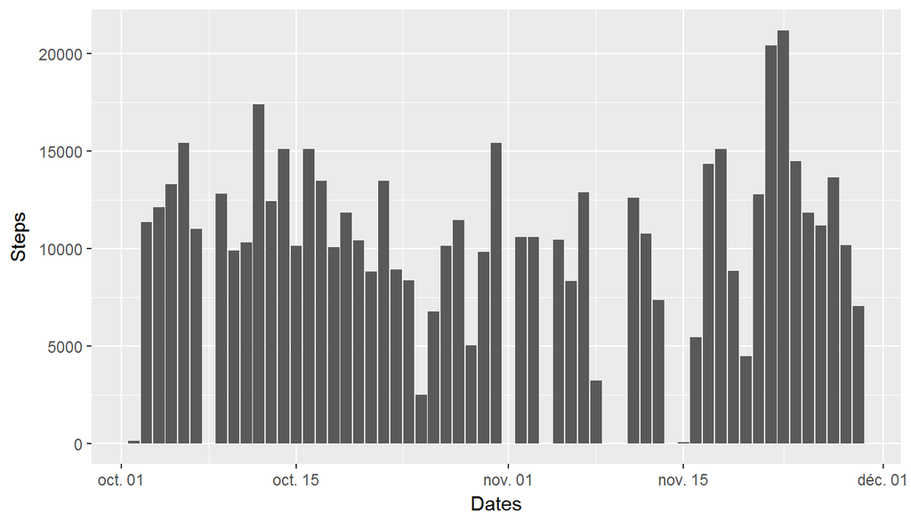

```r
print(plt)
```

In the second time, the median and the mean:

```r
# get the mean steps each days
meanActivityDataByDay <- tapply(activityData$steps, activityData$date, mean, na.rm = T, simplify = T)
# get the mean steps each days
medianActivityDataByDay <- tapply(activityData$steps, activityData$date, median, na.rm = T, simplify = T)
# group all the data
summaryActivityDataByDay <- data.frame(mean=meanActivityDataByDay, median=medianActivityDataByDay, date=names(meanActivityDataByDay), row.names = NULL)
# clean it
summaryActivityDataByDay <- summaryActivityDataByDay[!is.na(summaryActivityDataByDay$mea) | !is.na(summaryActivityDataByDay$med),]
#and display it
summaryActivityDataByDay
```

```
##          mean median       date
## 2   0.4375000      0 2012-10-02
## 3  39.4166667      0 2012-10-03
## 4  42.0694444      0 2012-10-04
## 5  46.1597222      0 2012-10-05
## 6  53.5416667      0 2012-10-06
## 7  38.2465278      0 2012-10-07
## 9  44.4826389      0 2012-10-09
## 10 34.3750000      0 2012-10-10
## 11 35.7777778      0 2012-10-11
## 12 60.3541667      0 2012-10-12
## 13 43.1458333      0 2012-10-13
## 14 52.4236111      0 2012-10-14
## 15 35.2048611      0 2012-10-15
## 16 52.3750000      0 2012-10-16
```

[output cut: 39 more lines]

In a third time, we look for the steps average for each day:

```r
plt <- ggplot(data=summaryActivityDataByDay, aes(x=as.Date(date), y = mean)) + geom_line() + ylab("mean steps") + xlab("Dates")
# save it
pdf("total-steps-average-by-days.pdf")
print(plt)
dev.off()
```

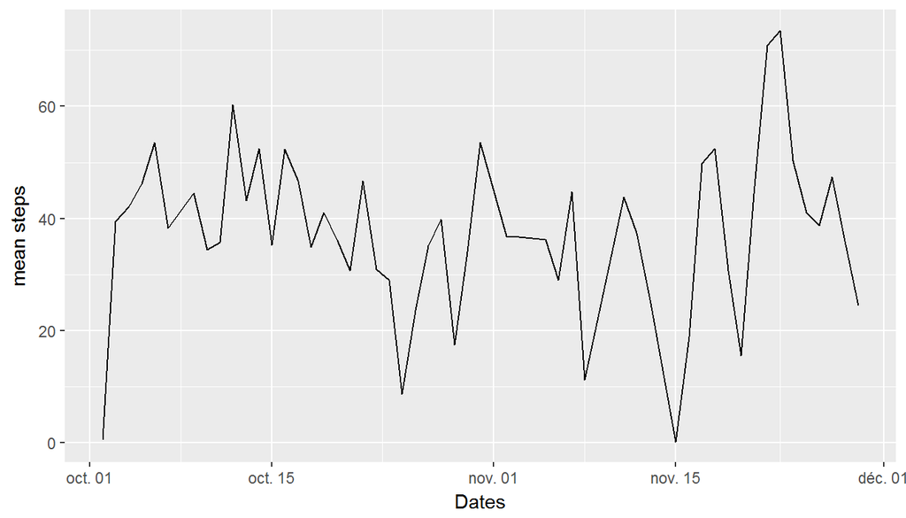

```r
print(plt)
```

At last, We will observe the 5 minutes interval that, on average, contains the maximum of steps:

```r
# compute the maximun of step by day with a rankink system
# the ranking is invert with the min method and the setps are invert too.
# We this we have just to subset on the first rank to know the maximum
activityData$rank <- ave(-activityData$steps, activityData$date, FUN=function(x) rank(x, ties.method = "min"))
# find the maximum
maxStepByDay <- subset(activityData, rank == 1)
# found the average interval
meanMaxInterval <- mean(maxStepByDay$interval)
```

We found as an answer: 1186.0909091

# Handle missing values

To well understand the importance of missing values imputing strategy we will first measure the number of missing values present in the current dataset.

```r
activityData <- read.csv(dataFileName)
# simple method
nbrNaValue <- sum(length(which(is.na(activityData$steps))))
```

We found 2304 Na values in the dataset.

There is a lot of strategies to handle missing values. In the code above, we chose the strategies of simply discarding the value.

```r
# example
summaryActivityDataByDay <- summaryActivityDataByDay[!is.na(summaryActivityDataByDay$mea) | !is.na(summaryActivityDataByDay$med),]
```

But other strategies are possible. Few are described in the following document: [missing data imputation](http://www.stat.columbia.edu/~gelman/arm/missing.pdf).

For the rest of this document I chose to use the **Simple missing-data approaches that retain all the data**. This method does not change the size of the dataset. The missing values are simply replaced by a new one. Different startegies are used to choose the value. In this example, we will just replace it by **the mean for that 5 min interval**.

```r
activityDataMeanForInterval <- tapply(activityData$steps, activityData$interval, na.rm=T, mean)
for (i in 1:nrow(activityData))
{
 if (is.na(activityData[i,"steps"]))
    activityData[i,"steps"] <- activityDataMeanForInterval[as.character(activityData[i, "interval"])]
}
head(activityData)
```

```
##       steps       date interval
## 1 1.7169811 2012-10-01        0
## 2 0.3396226 2012-10-01        5
## 3 0.1320755 2012-10-01       10
## 4 0.1509434 2012-10-01       15
## 5 0.0754717 2012-10-01       20
## 6 2.0943396 2012-10-01       25
```

With that strategy, we will be able to observe the impact of the imputation method on the final computation.

## Recompute the dataset

With this new missing value imputing strategies we recompute the total of steps done by the subject each day:

```r
library(ggplot2)
#clean data of na values with the new method
activityData[is.na(activityData)] <- 0
# plot it
plt <- ggplot(data=activityData, aes(x=as.Date(date), y = steps)) + geom_bar(stat="identity") + ylab("Steps") + xlab("Dates")
# save it
pdf("total-steps-by-days-imputing.pdf")
print(plt)
dev.off()
```

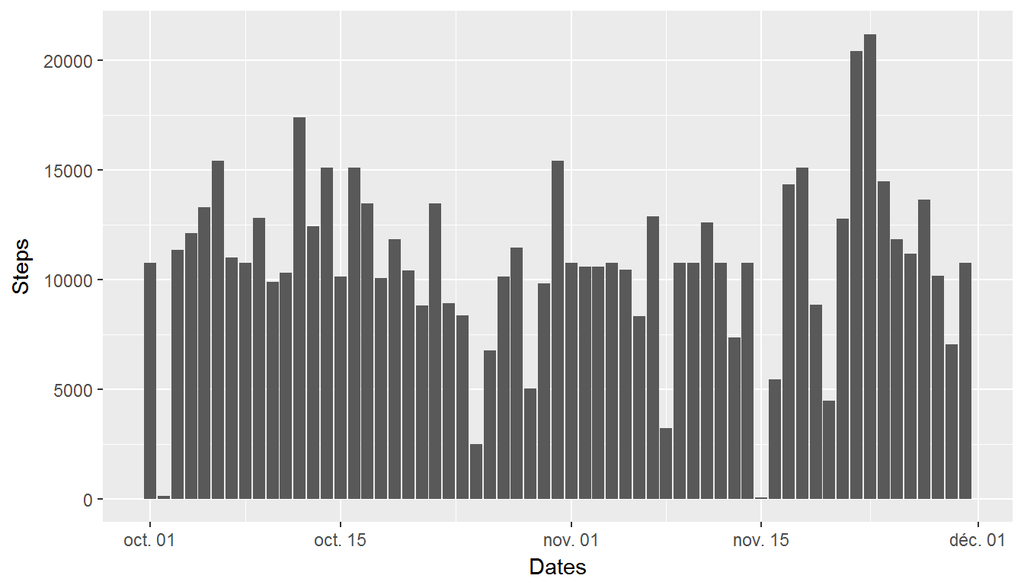

```r
print(plt)
```

And we recompute the mean and the median of those steps by days:

```r
# get the mean steps each days
meanActivityDataByDay <- tapply(activityData$steps, activityData$date, mean, na.rm = T, simplify = T)
# get the mean steps each days
medianActivityDataByDay <- tapply(activityData$steps, activityData$date, median, na.rm = T, simplify = T)
# group all the data
summaryActivityDataByDay <- data.frame(mean=meanActivityDataByDay, median=medianActivityDataByDay, date=names(meanActivityDataByDay), row.names = NULL)
# clean it
summaryActivityDataByDay <- summaryActivityDataByDay[!is.na(summaryActivityDataByDay$mea) | !is.na(summaryActivityDataByDay$med),]
#and display it
summaryActivityDataByDay
```

```
##          mean   median       date
## 1  37.3825996 34.11321 2012-10-01
## 2   0.4375000  0.00000 2012-10-02
## 3  39.4166667  0.00000 2012-10-03
## 4  42.0694444  0.00000 2012-10-04
## 5  46.1597222  0.00000 2012-10-05
## 6  53.5416667  0.00000 2012-10-06
## 7  38.2465278  0.00000 2012-10-07
## 8  37.3825996 34.11321 2012-10-08
## 9  44.4826389  0.00000 2012-10-09
## 10 34.3750000  0.00000 2012-10-10
## 11 35.7777778  0.00000 2012-10-11
## 12 60.3541667  0.00000 2012-10-12
## 13 43.1458333  0.00000 2012-10-13
## 14 52.4236111  0.00000 2012-10-14
```

[output cut: 47 more lines]

## Comparing data

For finish, we will plot the difference between the average number of steps per 5 minutes interval across the weekdays and the weekends.

```r
if (!require("chron"))
{
  install.packages("chron")
}
```

```r
library(chron)
par(mfrow=c(2, 1))

# found the appropriate day
activityData$daysweek <- sapply(as.Date(activityData$date), function(x)
  if (is.weekend(x))
    "weekend"
  else
    "weekday"
    )
# get the data by days
activityDataByWeekDays <- split(activityData, activityData$daysweek)
# get day names
dayWeekNames <- unique(activityData$daysweek)
# save it
pdf("comparing-weekday-weekend.pdf")
index <- 1
for (activityDataByWeekDay in activityDataByWeekDays)
{
  # get the data
  activityDataWeekDayByInterval <- tapply(activityDataByWeekDay$steps, activityDataByWeekDay$interval, mean)
  plot(activityDataWeekDayByInterval, main=dayWeekNames[index], ylab = "Average steps", xlab = "Interval", type="l")
  index <- index + 1
}
dev.off()
```

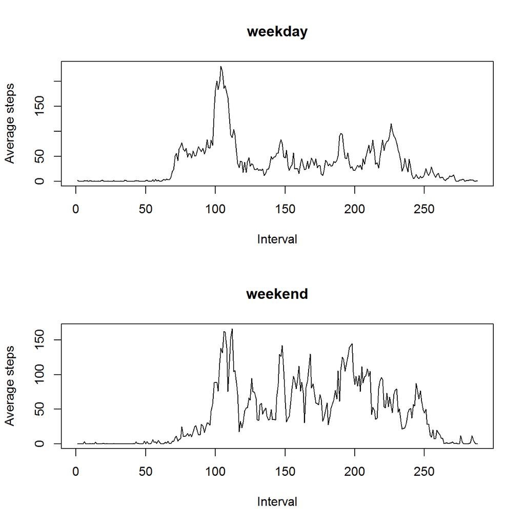

```r
# redisplay it trough current device
index <- 1
for (activityDataByWeekDay in activityDataByWeekDays)
{
  # get the data
  activityDataWeekDayByInterval <- tapply(activityDataByWeekDay$steps, activityDataByWeekDay$interval, mean)
  plot(activityDataWeekDayByInterval, main=dayWeekNames[index], ylab = "Average steps", xlab = "Interval", type="l")
  index <- index + 1
}
```